# 1.1 Introduction to Deep Learning

Regression

Rick Scavetta

# Session 1

## Functions & Take-home Message

### Learning Goals

Developing deep learning to two core questions in supervised learning: Classification and Regression.

### Outline

- What is a tensor and why use it?
- What is keras and what is its relationship to TensorFlow?
- What is the deep in deep learning? ANNs and densely-connected networks.
- The math of deep learning: Basics of matrix algebra, gradient descent, backpropagarion, chain rule.
- The four stages of Deep learning.
- Parameters and hyper-parameter.
- Functions distinguishing classification and regression: loss and optimizer functions.

### Functions in this session:

Basic `keras` functions:

| Function | Description |
| --- | --- |
| [`keras_model_sequential()`](https://www.rdocumentation.org/packages/keras/versions/2.2.0/topics/keras_model_sequential) | Keras network (model) composed of a linear stack of layers. |
| `layer_dense()` | Add a densely-connected NN layer to an output. |
| `compile()` | Configure a Keras model for training. |
| `fit()` | Train a Keras model. |

### Take-home Message

In this case study, we’ll perform a regression to predict a continouous response variable from 13 predictor variables. That means we’ll use:

- Z-scores normalization for the predictor variables.

Plus the following functions in our network

| Name | Function |
| --- | --- |
| Loss function | `mse` |
| Metric | `mae` |
| last-layer activation function | none (i.e. scalar) |

### Install tensorflow

We’ve already done this for you. On your own machines you’ll have to run this once, after you have installed the keras package

```r
install.packages("keras")

# for GPU
# install_keras(tensorflow = "gpu")

# or CPU:
install_keras() # for cpu
```

## Part 1: Data Preparation

### Obtain data

```r
c(c(train_data, train_targets), c(test_data, test_targets)) %<-% dataset_boston_housing()
```

### Examine data:

Our predictor variables:

```r
str(train_data)
```

```
##  num [1:404, 1:13] 1.2325 0.0218 4.8982 0.0396 3.6931 ...
```

```r
str(test_data)
```

```
##  num [1:102, 1:13] 18.0846 0.1233 0.055 1.2735 0.0715 ...
```

The target, response variable:

```r
str(train_targets)
```

```
##  num [1:404(1d)] 15.2 42.3 50 21.1 17.7 18.5 11.3 15.6 15.6 14.4 ...
```

### Prepare the data:

Convert z-scores:

$$z_i=\frac{x_i-\bar{x}}{s}$$

```r
# parameters for Scaling:
mean <- colMeans(train_data) # mean of each column
std <- apply(train_data, 2, sd) # stdev of each column

# Calculate feature-wise (within-variable) z-scores: (x - mean)/std
train_data <- scale(train_data, center = mean, scale = std)
test_data <- scale(test_data, center = mean, scale = std)
```

```r
summary(train_data)
```

```
##        V1                  V2                 V3
##  Min.   :-0.404599   Min.   :-0.48302   Min.   :-1.5628
##  1st Qu.:-0.396470   1st Qu.:-0.48302   1st Qu.:-0.8771
##  Median :-0.376186   Median :-0.48302   Median :-0.2077
##  Mean   : 0.000000   Mean   : 0.00000   Mean   : 0.0000
##  3rd Qu.:-0.007608   3rd Qu.: 0.04291   3rd Qu.: 1.0271
##  Max.   : 9.223411   Max.   : 3.72437   Max.   : 2.4423
##        V4                V5                V6                 V7
##  Min.   :-0.2565   Min.   :-1.4694   Min.   :-3.81252   Min.   :-2.3661
##  1st Qu.:-0.2565   1st Qu.:-0.8897   1st Qu.:-0.55275   1st Qu.:-0.8423
##  Median :-0.2565   Median :-0.1650   Median :-0.09662   Median : 0.3396
##  Mean   : 0.0000   Mean   : 0.0000   Mean   : 0.00000   Mean   : 0.0000
##  3rd Qu.:-0.2565   3rd Qu.: 0.6279   3rd Qu.: 0.48172   3rd Qu.: 0.8980
##  Max.   : 3.8888   Max.   : 2.6740   Max.   : 3.46289   Max.   : 1.1091
##        V8                V9               V10               V11
##  Min.   :-1.2859   Min.   :-0.9704   Min.   :-1.3097   Min.   :-2.6704
##  1st Qu.:-0.8192   1st Qu.:-0.6255   1st Qu.:-0.7627   1st Qu.:-0.5685
##  Median :-0.2945   Median :-0.5105   Median :-0.4562   Median : 0.2836
##  Mean   : 0.0000   Mean   : 0.0000   Mean   : 0.0000   Mean   : 0.0000
##  3rd Qu.: 0.6786   3rd Qu.: 1.6738   3rd Qu.: 1.5633   3rd Qu.: 0.7835
##  Max.   : 3.4331   Max.   : 1.6738   Max.   : 1.8338   Max.   : 1.6015
##       V12               V13
##  Min.   :-3.7664   Min.   :-1.5178
##  1st Qu.: 0.2113   1st Qu.:-0.8065
##  Median : 0.3875   Median :-0.1855
##  Mean   : 0.0000   Mean   : 0.0000
##  3rd Qu.: 0.4396   3rd Qu.: 0.5999
##  Max.   : 0.4475   Max.   : 3.4777
```

```r
summary(test_data)
```

```
##        V1                  V2                 V3
##  Min.   :-0.403864   Min.   :-0.48302   Min.   :-1.45118
##  1st Qu.:-0.396102   1st Qu.:-0.48302   1st Qu.:-0.82942
##  Median :-0.380500   Median :-0.48302   Median :-0.19224
##  Mean   :-0.070641   Mean   :-0.02433   Mean   : 0.02356
##  3rd Qu.: 0.003716   3rd Qu.: 0.20068   3rd Qu.: 1.02705
##  Max.   : 2.305119   Max.   : 3.30363   Max.   : 2.44235
##        V4                V5                V6                 V7
##  Min.   :-0.2565   Min.   :-1.4098   Min.   :-1.95422   Min.   :-2.25516
##  1st Qu.:-0.2565   1st Qu.:-0.9536   1st Qu.:-0.42419   1st Qu.:-0.95061
##  Median :-0.2565   Median :-0.2162   Median :-0.05365   Median : 0.16962
##  Mean   : 0.1499   Mean   :-0.1125   Mean   : 0.12268   Mean   :-0.07736
##  3rd Qu.:-0.2565   3rd Qu.: 0.4403   3rd Qu.: 0.51659   3rd Qu.: 0.85769
##  Max.   : 3.8888   Max.   : 2.6740   Max.   : 3.54038   Max.   : 1.10911
##        V8                V9                V10
##  Min.   :-1.1205   Min.   :-0.97037   Min.   :-1.31570
##  1st Qu.:-0.7994   1st Qu.:-0.62547   1st Qu.:-0.76123
##  Median :-0.2046   Median :-0.51051   Median :-0.45619
##  Mean   : 0.1338   Mean   : 0.06206   Mean   : 0.06973
##  3rd Qu.: 0.7568   3rd Qu.: 1.67381   3rd Qu.: 1.56335
##  Max.   : 4.1307   Max.   : 1.67381   Max.   : 1.83382
##       V11                V12                V13
##  Min.   :-2.48865   Min.   :-3.50791   Min.   :-1.49159
##  1st Qu.:-0.48900   1st Qu.: 0.24343   1st Qu.:-0.74930
##  Median : 0.19270   Median : 0.39663   Median :-0.23169
##  Mean   :-0.04612   Mean   : 0.09967   Mean   :-0.06001
##  3rd Qu.: 0.78350   3rd Qu.: 0.44625   3rd Qu.: 0.43754
##  Max.   : 1.23797   Max.   : 0.44752   Max.   : 2.65340
```

### Targets

The targes remain unchanged:

```r
summary(train_targets)
```

```
##    Min. 1st Qu.  Median    Mean 3rd Qu.    Max.
##    5.00   16.68   20.75   22.40   24.80   50.00
```

```r
summary(test_targets)
```

```
##    Min. 1st Qu.  Median    Mean 3rd Qu.    Max.
##    5.60   18.65   21.95   23.08   27.07   50.00
```

## Part 2: Define Network

### Define the network as a function

Here, I’ve hardcoded the number of features for this dataset (`13`). To generalize, we could just use `dim(train_data)[2]` to get the number of dimensions from the training set.

```r
network <- keras_model_sequential() %>%
  layer_dense(units = 64, activation = "relu", input_shape = 13) %>%
  layer_dense(units = 64, activation = "relu") %>%
  layer_dense(units = 1)

network %>% compile(
  optimizer = "rmsprop",
  loss = "mse",
  metrics = "mae"
)
```

Note two key functions that I mentioned earlier. The mean squared error:

$$\operatorname{MSE} = \frac{\sum_{i=1}^n(y_i-\hat{y_i})^2}{n} = \frac{\sum_{i=1}^n{e_i^2}}{n}$$
and the mean absolute error (MAE):

$$\mathrm{MAE} = \frac{\sum_{i=1}^n\left| y_i-\hat{y_i}\right|}{n} = \frac{\sum_{i=1}^n\left| e_i\right|}{n}$$
where $\hat{y_i}$ is the predicted value, given in our last single-unit layer, and $y_i$ is the actual value, the target.

## Training

We need to decide how many epochs to run our model plus the size and the number of the hidden layers.we’ll train our model on the training data, then look at its performance on the test data:

`verbose = TRUE` prints all the values to the screen. That’s fine, but we can also save the results to an object as it trains:

```r
history <- network %>%
  fit(train_data,
      train_targets,
      epochs = 120,
      batch_size = 16)
```

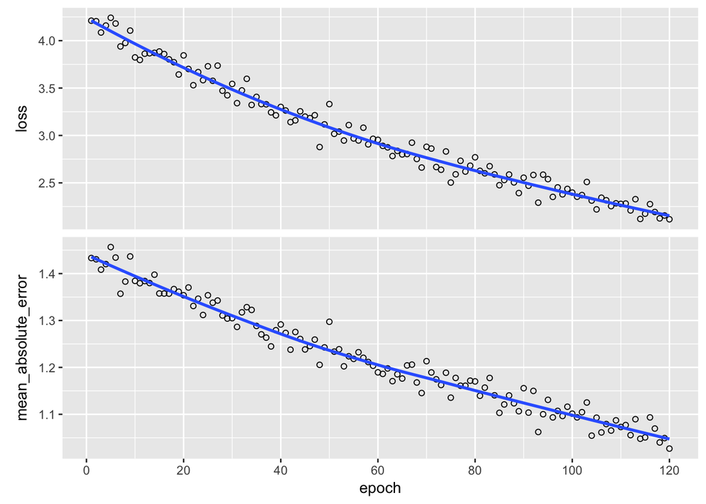

```r
plot(history)
```

## Model Evaluation:

```r
result <- network %>%
  evaluate(test_data, test_targets)
```

### Results:

```r
MAE_dl <- result$mean_absolute_error
```

```r
result
```

```
## $loss
## [1] 13.25669
##
## $mean_absolute_error
## [1] 2.517273
```

The MAE, using deep learning, is 2.5172728. In dollar amounts, we are still off by $2517.27. That’s much better than with the LM, but actually not really an improvement on a random forest.

To get the actual predictions we can use the `predict()` function:

```r
network %>%
  predict(test_data) %>%
  head()
```

```
##           [,1]
## [1,]  7.225235
## [2,] 17.569941
## [3,] 19.119623
## [4,] 31.786552
## [5,] 23.667791
## [6,] 22.169119
```

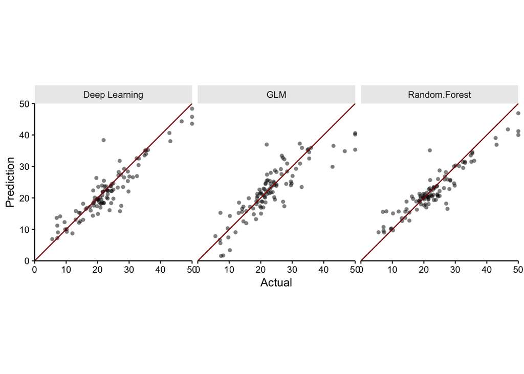